# Cross-Experiment Survivorship Summary & Family Ranking

Author

Steven Roberts

Published

July 21, 2026

BACKGROUND - This document pools EVERY *Magallana gigas* USDA-family survivorship experiment run to date into a single analysis, harmonising the two different raw data layouts used across dates, and then ranks families by as many survival phenotypes as the data support.

Experiments included (see each `data/<date>-.../README.md` for full protocols):

| exp_id | date | stressor | raw format |
| --- | --- | --- | --- |
| 20260427-33C | 2026-04-27 | 33 °C | long (`alive.measurement`) |
| 20260511-33C | 2026-05-11 | 33 °C | long (`alive.measurement`) |
| 20260604-36C | 2026-06-04 | 36 °C | wide (mortality 0/1) |
| 20260609-36C | 2026-06-09 | 36 °C | long (`alive.measurement`) |
| 20260706-35C | 2026-07-06 | 35 °C | wide (mortality 0/1) |
| 20260706-35C09ppt | 2026-07-06 | 35 °C + 9 ppt | wide (mortality 0/1) |
| 20260707-FW | 2026-07-07 | freshwater → 36 °C | wide (mortality 0/1) |

The 20260714-H2O2FW experiment has a protocol README but no scored `survivorship.csv` yet, so it is not included.

**Note on the 9 / 9b label ambiguity:** the 20260511 and 20260609 experiments each contain both a `9` and a `9b` family and are missing family `2`. One of the two 9-labels in those experiments is really family 2 and the other is really family 9, but the correct assignment was lost. Because any guess would be a 50/50 that corrupts *both* family 2 and family 9, all `9`/`9b` individuals are **excluded** from those two experiments (family 9 is retained wherever it appears unambiguously; family `9b` drops out entirely).

## Set up

```r
library(tidyverse)
library(survival)
library(ggsurvfit)
library(knitr)

out_dir <- "../outputs/09-mgig-survivorship-cross-experiment-summary/"
dir.create(out_dir, showWarnings = FALSE, recursive = TRUE)
```

## Experiment registry

```r
experiments <- tibble::tribble(
  ~exp_id,               ~date,        ~stressor,             ~format, ~path,
  "20260427-33C",        "2026-04-27", "33 C",                "long",  "../data/20260427-33C-USDA-families/survivorship.csv",
  "20260511-33C",        "2026-05-11", "33 C",                "long",  "../data/20260511-33C-USDA-families/survivorship.csv",
  "20260604-36C",        "2026-06-04", "36 C",                "wide",  "../data/20260604-36C-USDA-families/survivorship.csv",
  "20260609-36C",        "2026-06-09", "36 C",                "long",  "../data/20260609-36C-USDA-families/survivorship.csv",
  "20260706-35C",        "2026-07-06", "35 C",                "wide",  "../data/20260706-35C-USDA-families/survivorship.csv",
  "20260706-35C09ppt",   "2026-07-06", "35 C / 9 ppt",        "wide",  "../data/20260706-35C09ppt-USDA-families/survivorship.csv",
  "20260707-FW",         "2026-07-07", "Freshwater -> 36 C",  "wide",  "../data/20260707-FW-USDA-families/survivorship.csv"
)
knitr::kable(experiments |> dplyr::select(-path))
```

| exp_id | date | stressor | format |
| --- | --- | --- | --- |
| 20260427-33C | 2026-04-27 | 33 C | long |
| 20260511-33C | 2026-05-11 | 33 C | long |
| 20260604-36C | 2026-06-04 | 36 C | wide |
| 20260609-36C | 2026-06-09 | 36 C | long |
| 20260706-35C | 2026-07-06 | 35 C | wide |
| 20260706-35C09ppt | 2026-07-06 | 35 C / 9 ppt | wide |
| 20260707-FW | 2026-07-07 | Freshwater -> 36 C | wide |

## Harmonise all experiments to one (family, individual, time, status) table

```r
# Normalise family labels: strip a leading "f" and zero-padding so "f01","01","1"
# all become "1"; non-numeric labels such as "9b" are kept verbatim (lower-cased).
norm_family <- function(x) {
  x <- tolower(trimws(as.character(x)))
  x <- sub("^f", "", x)          # f01 -> 01, f2 -> 2, 9b unchanged
  x <- ifelse(grepl("^[0-9]+$", x), as.character(as.integer(x)), x)  # 01 -> 1
  x
}

# ---- LONG format: alive.measurement TRUE = alive, one row per indiv x timepoint
read_long <- function(path) {
  df <- readr::read_csv(path, show_col_types = FALSE, name_repair = "minimal")
  names(df) <- trimws(names(df))
  if ("is_blank" %in% names(df)) {
    df <- df %>% filter(is.na(is_blank) | tolower(as.character(is_blank)) != "true")
  }
  df %>%
    transmute(
      uid        = as.character(individual_id),
      family_raw = as.character(familly_id.group),
      time       = as.numeric(timepoint_hrs),
      dead       = !as.logical(alive.measurement)
    ) %>%
    filter(!is.na(uid), !is.na(time), !is.na(dead))
}

# ---- WIDE format: numeric-named timepoint columns, cell 1 = dead
read_wide <- function(path) {
  df <- readr::read_csv(path, show_col_types = FALSE, name_repair = "minimal")
  names(df) <- trimws(gsub("", "", names(df)))          # drop BOM/whitespace
  time_cols <- names(df)[grepl("^[0-9]+$", names(df))]
  fam_col   <- names(df)[grepl("^family$", names(df), ignore.case = TRUE)][1]
  df %>%
    mutate(uid = paste0("row", row_number())) %>%             # one row = one indiv
    rename(family_raw = !!fam_col) %>%
    filter(!is.na(family_raw), trimws(as.character(family_raw)) != "") %>%
    pivot_longer(all_of(time_cols), names_to = "time", values_to = "dead_raw") %>%
    transmute(
      uid        = as.character(uid),
      family_raw = as.character(family_raw),
      time = as.numeric(time),
      dead = toupper(trimws(as.character(dead_raw))) %in% c("1","TRUE","T","DEAD","YES","Y")
    ) %>%
    filter(!is.na(time))
}

read_exp <- function(fmt, path) if (fmt == "long") read_long(path) else read_wide(path)
```

```r
# Collapse each individual to ONE (time, status) row within its experiment:
#   status = 1 if ever dead (event); time = first death time, else last timepoint.
indiv0 <- experiments %>%
  mutate(raw = purrr::map2(format, path, read_exp)) %>%
  select(exp_id, date, stressor, raw) %>%
  unnest(raw) %>%
  mutate(family = norm_family(family_raw)) %>%
  group_by(exp_id, date, stressor, family, uid) %>%
  summarise(
    status = as.integer(any(dead, na.rm = TRUE)),
    time   = if (any(dead, na.rm = TRUE)) min(time[dead], na.rm = TRUE) else max(time, na.rm = TRUE),
    .groups = "drop"
  )
# ---- Resolve the 9 / 9b mislabelling -----------------------------------------
# In experiments where BOTH "9" and "9b" were run, family 2 is ABSENT: one of the
# two 9-labels is really family 2 and the other is really family 9, but which is
# which was lost at labelling. Rather than guess (a 50/50 that would corrupt BOTH
# family 2 and family 9), we EXCLUDE every "9" and "9b" individual from those
# experiments. In experiments where only "9" appears it is unambiguous family 9
# and is kept; family "9b" therefore drops out of the analysis entirely.
amb_exps <- indiv0 %>%
  group_by(exp_id) %>%
  summarise(both = all(c("9", "9b") %in% family), .groups = "drop") %>%
  filter(both) %>% pull(exp_id)

n_dropped <- indiv0 %>%
  filter(exp_id %in% amb_exps, family %in% c("9", "9b")) %>% nrow()

indiv <- indiv0 %>%
  filter(!(exp_id %in% amb_exps & family %in% c("9", "9b"))) %>%
  group_by(exp_id) %>%
  mutate(tau = max(time)) %>%          # experiment observation window (hrs)
  ungroup()

cat("Experiments with unresolved 9/9b labels (9 & 9b excluded there):",
    ifelse(length(amb_exps) == 0, "none", paste(amb_exps, collapse = ", ")), "\n")
```

```
Experiments with unresolved 9/9b labels (9 & 9b excluded there): 20260511-33C, 20260609-36C
```

```r
cat("Individuals dropped due to 9/9b ambiguity:", n_dropped, "\n")
```

```
Individuals dropped due to 9/9b ambiguity: 46
```

```r
cat("Total individuals pooled:", nrow(indiv),
    "| experiments:", dplyr::n_distinct(indiv$exp_id),
    "| families:", dplyr::n_distinct(indiv$family), "\n")
```

```
Total individuals pooled: 1095 | experiments: 7 | families: 9
```

```r
cat("Family labels seen:", paste(sort(unique(indiv$family)), collapse = ", "), "\n")
```

```
Family labels seen: 1, 10, 2, 3, 5, 6, 7, 8, 9
```

## Per-experiment performance summary

```r
exp_summary <- indiv %>%
  group_by(exp_id, date, stressor) %>%
  group_modify(function(d, key) {
    fit_all <- survival::survfit(Surv(time, status) ~ 1, data = d)
    med <- summary(fit_all)$table["median"]
    # family log-rank (only if >1 family with events possible)
    p_lr <- NA_real_
    if (dplyr::n_distinct(d$family) > 1) {
      lr <- survival::survdiff(Surv(time, status) ~ family, data = d)
      p_lr <- 1 - pchisq(lr$chisq, df = length(lr$n) - 1)
    }
    tibble(
      n            = nrow(d),
      n_families   = dplyr::n_distinct(d$family),
      deaths       = sum(d$status),
      mortality_pct = round(100 * mean(d$status), 1),
      tau_hrs      = max(d$time),
      median_surv_hrs = ifelse(is.na(med), NA, unname(med)),
      logrank_p    = signif(p_lr, 3)
    )
  }) %>%
  ungroup() %>%
  arrange(date)

knitr::kable(exp_summary, caption = "Per-experiment survivorship summary")
```

Per-experiment survivorship summary

| exp_id | date | stressor | n | n_families | deaths | mortality_pct | tau_hrs | median_surv_hrs | logrank_p |
| --- | --- | --- | --- | --- | --- | --- | --- | --- | --- |
| 20260427-33C | 2026-04-27 | 33 C | 128 | 9 | 63 | 49.2 | 99.5 | NA | 1.44e-01 |
| 20260511-33C | 2026-05-11 | 33 C | 84 | 7 | 83 | 98.8 | 67.0 | 27 | 7.61e-04 |
| 20260604-36C | 2026-06-04 | 36 C | 39 | 8 | 37 | 94.9 | 42.0 | 24 | 9.76e-03 |
| 20260609-36C | 2026-06-09 | 36 C | 77 | 7 | 66 | 85.7 | 52.0 | 48 | 2.42e-02 |
| 20260706-35C | 2026-07-06 | 35 C | 378 | 9 | 366 | 96.8 | 163.0 | 43 | 5.94e-02 |
| 20260706-35C09ppt | 2026-07-06 | 35 C / 9 ppt | 204 | 9 | 171 | 83.8 | 167.0 | 167 | 5.04e-02 |
| 20260707-FW | 2026-07-07 | Freshwater -> 36 C | 185 | 9 | 61 | 33.0 | 188.0 | NA | 7.73e-05 |

```r
readr::write_csv(exp_summary, file.path(out_dir, "experiment_summary.csv"))
```

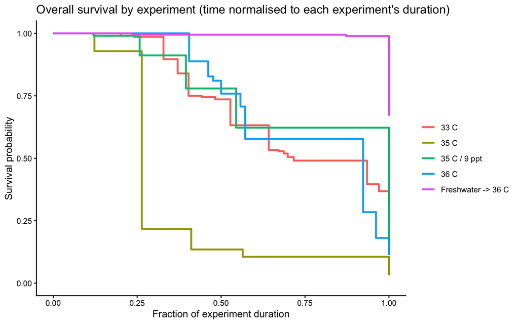

```r
# Overall KM curve per experiment on a common (normalised) time axis so severity
# is directly comparable regardless of experiment duration.
indiv_norm <- indiv %>% mutate(time_frac = time / tau)

km_overall <- survival::survfit(Surv(time_frac, status) ~ exp_id, data = indiv_norm)
p_overall <- ggsurvfit::survfit2(Surv(time_frac, status) ~ stressor, data = indiv_norm) %>%
  ggsurvfit::ggsurvfit(linewidth = 1) +
  labs(x = "Fraction of experiment duration", y = "Survival probability",
       title = "Overall survival by experiment (time normalised to each experiment's duration)") +
  ylim(0, 1) +
  theme_classic() +
  theme(legend.position = "right")
p_overall
```

```r
ggsave(file.path(out_dir, "km_overall_by_experiment.png"), p_overall, width = 8, height = 5, dpi = 300)
```

## Family phenotypes within each experiment

```r
# Two phenotypes per family x experiment (both 0-1, higher = better):
#   surv_prop     = fraction alive at end
#   rel_surv_time = mean restricted lifetime / tau  (= normalised RMST)
fam_exp <- indiv %>%
  group_by(exp_id, date, stressor, family, tau) %>%
  summarise(
    n             = dplyr::n(),
    deaths        = sum(status),
    surv_prop     = mean(status == 0),
    rel_surv_time = mean(ifelse(status == 1, time, tau)) / dplyr::first(tau),
    .groups = "drop"
  ) %>%
  # within-experiment percentile (0-100) for each phenotype; ties share mean rank
  group_by(exp_id) %>%
  mutate(
    pct_surv = 100 * (rank(surv_prop,     ties.method = "average") - 0.5) / dplyr::n(),
    pct_rst  = 100 * (rank(rel_surv_time, ties.method = "average") - 0.5) / dplyr::n()
  ) %>%
  ungroup()

readr::write_csv(fam_exp, file.path(out_dir, "family_by_experiment.csv"))
```

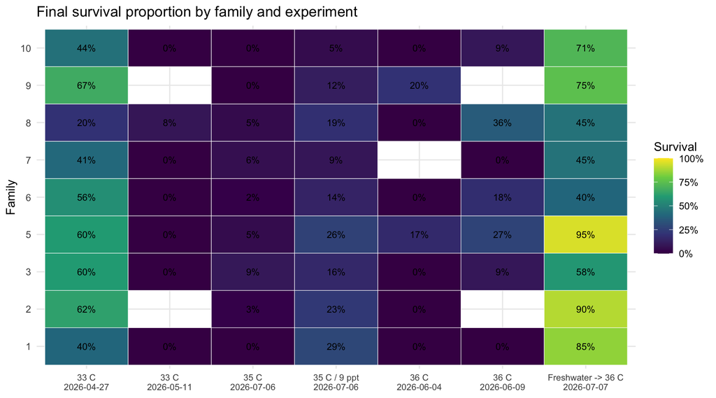

```r
hm <- fam_exp %>%
  mutate(
    family = factor(family, levels = unique(family[order(readr::parse_number(family), family)])),
    exp_lab = paste0(stressor, "\n", date)
  )
p_hm <- ggplot(hm, aes(x = exp_lab, y = family, fill = surv_prop)) +
  geom_tile(color = "white") +
  geom_text(aes(label = sprintf("%.0f%%", 100 * surv_prop)), size = 3) +
  scale_fill_viridis_c(name = "Survival", limits = c(0, 1), labels = scales::percent) +
  labs(x = NULL, y = "Family",
       title = "Final survival proportion by family and experiment") +
  theme_minimal() +
  theme(axis.text.x = element_text(size = 8))
p_hm
```

```r
ggsave(file.path(out_dir, "family_survival_heatmap.png"), p_hm, width = 9, height = 5, dpi = 300)
```

## Family ranking across all experiments

```r
family_rank <- fam_exp %>%
  group_by(family) %>%
  summarise(
    n_experiments   = dplyr::n(),
    total_n         = sum(n),
    total_deaths    = sum(deaths),
    overall_mort_pct = round(100 * sum(deaths) / sum(n), 1),
    mean_surv_prop  = round(mean(surv_prop), 3),
    mean_rel_surv   = round(mean(rel_surv_time), 3),
    composite_score = round(mean((pct_surv + pct_rst) / 2), 1),  # 0-100, higher = better
    .groups = "drop"
  ) %>%
  arrange(desc(composite_score)) %>%
  mutate(rank = dplyr::row_number()) %>%
  select(rank, family, n_experiments, total_n, overall_mort_pct,
         mean_surv_prop, mean_rel_surv, composite_score)

knitr::kable(family_rank,
             caption = "Family ranking (composite = mean within-experiment percentile across survival phenotypes; higher = hardier)")
```

Family ranking (composite = mean within-experiment percentile across survival phenotypes; higher = hardier)

| rank | family | n_experiments | total_n | overall_mort_pct | mean_surv_prop | mean_rel_surv | composite_score |
| --- | --- | --- | --- | --- | --- | --- | --- |
| 1 | 5 | 7 | 129 | 67.4 | 0.329 | 0.787 | 71.0 |
| 2 | 9 | 5 | 119 | 75.6 | 0.346 | 0.794 | 63.2 |
| 3 | 2 | 5 | 92 | 68.5 | 0.356 | 0.715 | 59.0 |
| 4 | 8 | 7 | 123 | 82.1 | 0.190 | 0.701 | 52.7 |
| 5 | 3 | 7 | 121 | 72.7 | 0.218 | 0.695 | 48.8 |
| 6 | 1 | 7 | 128 | 75.8 | 0.219 | 0.703 | 46.9 |
| 7 | 6 | 7 | 122 | 84.4 | 0.186 | 0.671 | 40.8 |
| 8 | 10 | 7 | 116 | 81.9 | 0.185 | 0.671 | 36.7 |
| 9 | 7 | 6 | 145 | 84.8 | 0.168 | 0.691 | 35.3 |

```r
readr::write_csv(family_rank, file.path(out_dir, "family_ranking.csv"))
```

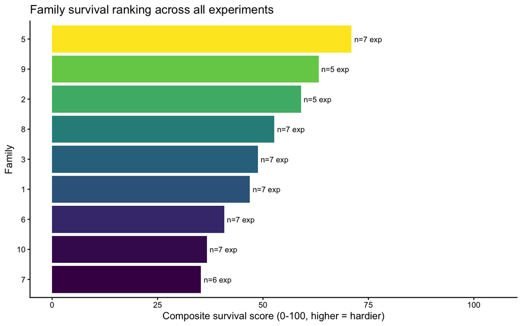

```r
p_rank <- family_rank %>%
  mutate(family = forcats::fct_reorder(family, composite_score)) %>%
  ggplot(aes(x = composite_score, y = family, fill = composite_score)) +
  geom_col() +
  geom_text(aes(label = paste0("n=", n_experiments, " exp")), hjust = -0.1, size = 3) +
  scale_fill_viridis_c(guide = "none") +
  xlim(0, 105) +
  labs(x = "Composite survival score (0-100, higher = hardier)", y = "Family",
       title = "Family survival ranking across all experiments") +
  theme_classic()
p_rank
```

```r
ggsave(file.path(out_dir, "family_ranking.png"), p_rank, width = 8, height = 5, dpi = 300)
```

## Consistency check: within-experiment survival percentile by family

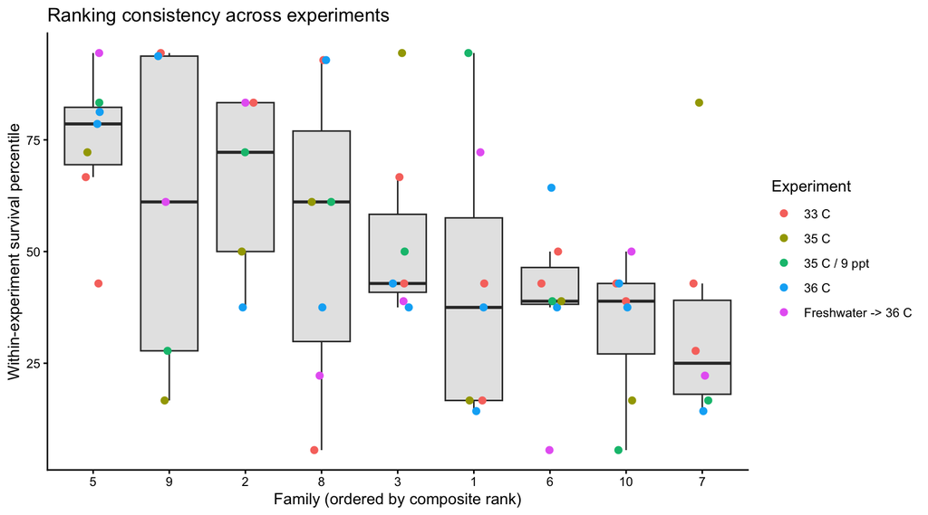

```r
p_cons <- fam_exp %>%
  mutate(family = factor(family, levels = family_rank$family)) %>%
  ggplot(aes(x = family, y = pct_surv)) +
  geom_boxplot(outlier.shape = NA, fill = "grey90") +
  geom_jitter(aes(color = stressor), width = 0.15, height = 0, size = 2) +
  labs(x = "Family (ordered by composite rank)", y = "Within-experiment survival percentile",
       title = "Ranking consistency across experiments",
       color = "Experiment") +
  theme_classic()
p_cons
```

```r
ggsave(file.path(out_dir, "family_consistency.png"), p_cons, width = 9, height = 5, dpi = 300)
```

## Take homes

```r
best  <- family_rank %>% slice_head(n = 3)
worst <- family_rank %>% slice_tail(n = 3)

cat("Experiments pooled:", nrow(exp_summary), "\n")
```

```
Experiments pooled: 7
```

```r
cat("Total individuals:", sum(exp_summary$n),
    "| overall deaths:", sum(exp_summary$deaths), "\n\n")
```

```
Total individuals: 1095 | overall deaths: 847
```

```r
cat("Most heat/stress tolerant families (top composite score):\n")
```

```
Most heat/stress tolerant families (top composite score):
```

```r
for (i in seq_len(nrow(best))) {
  cat(sprintf("  %d. Family %s  (score %.1f, mean survival %.0f%%, %d experiments)\n",
              best$rank[i], best$family[i], best$composite_score[i],
              100 * best$mean_surv_prop[i], best$n_experiments[i]))
}
```

```
  1. Family 5  (score 71.0, mean survival 33%, 7 experiments)
  2. Family 9  (score 63.2, mean survival 35%, 5 experiments)
  3. Family 2  (score 59.0, mean survival 36%, 5 experiments)
```

```r
cat("\nLeast tolerant families (bottom composite score):\n")
```

```
Least tolerant families (bottom composite score):
```

```r
for (i in seq_len(nrow(worst))) {
  cat(sprintf("  %d. Family %s  (score %.1f, mean survival %.0f%%, %d experiments)\n",
              worst$rank[i], worst$family[i], worst$composite_score[i],
              100 * worst$mean_surv_prop[i], worst$n_experiments[i]))
}
```

```
  7. Family 6  (score 40.8, mean survival 19%, 7 experiments)
  8. Family 10  (score 36.7, mean survival 18%, 7 experiments)
  9. Family 7  (score 35.3, mean survival 17%, 6 experiments)
```